# Custom Models : Neural Networks with Keras

In this notebook, we will use the [Keras library](https://keras.io/getting_started/) to implement different Artificial Neural Network (ANN) models.

We will compare these models to the baseline model from 1_baseline.ipynb.

## Load project modules and data

We will use basic python packages, as well as [Tensorflow](https://www.tensorflow.org/guide) and [`Keras`](https://radimrehurek.com/gensim/intro.html) to build our Neural Network models.

```python
import pickle
from tqdm import tqdm

# Import custom helper libraries
import os
import sys

src_path = os.path.abspath(os.path.join("../src"))
if src_path not in sys.path:
    sys.path.append(src_path)

import data.helpers as data_helpers
import visualization.helpers as viz_helpers

# Maths modules
import numpy as np
import pandas as pd
import tensorflow as tf

# Render for export
import plotly.io as pio

pio.renderers.default = "notebook"
```

```
2022-02-02 12:21:49.261031: W tensorflow/stream_executor/platform/default/dso_loader.cc:64] Could not load dynamic library 'libcudart.so.11.0'; dlerror: libcudart.so.11.0: cannot open shared object file: No such file or directory
2022-02-02 12:21:49.261062: I tensorflow/stream_executor/cuda/cudart_stub.cc:29] Ignore above cudart dlerror if you do not have a GPU set up on your machine.
```

```python
# Download and unzip CSV files
!cd .. && make dataset && cd notebooks
```

```
>>> Downloading and extracting data files...
Data files already downloaded.
>>> OK.
```

```python
# Load data from CSV
df = pd.read_csv(
    os.path.join("..", "data", "raw", "training.1600000.processed.noemoticon.csv"),
    names=["target", "id", "date", "flag", "user", "text"],
)

# Reduce memory usage
df = data_helpers.reduce_dataframe_memory_usage(df)

# Drop useless columns
df.drop(columns=["id", "date", "flag", "user"], inplace=True)

# Replace target values with labels
df.target = df.target.map(
    {
        0: "NEGATIVE",
        2: "NEUTRAL",
        4: "POSITIVE",
    }
)

# Binarize target
df.target = df.target.map(
    {
        "NEGATIVE": 0,
        "POSITIVE": 1,
    }
)

df.describe()
```

|  | target |
| --- | --- |
| count | 1600000.0 |
| mean | 0.5 |
| std | 0.5 |
| min | 0.0 |
| 25% | 0.0 |
| 50% | 0.5 |
| 75% | 1.0 |
| max | 1.0 |

## Basic FFNN (Feed Forward Neural Network) model

### FFNN on simple word count vectors

In this model, we will use a simple word count vector as our input, with no text preprocessing. The Neural Network architecture will be a simple feed forward network with two hidden layer.

```python
from sklearn.model_selection import train_test_split

# Train-test split
X_train, X_test, y_train, y_test = train_test_split(
    df.text,
    df.target,
    test_size=0.2,
    stratify=df.target,
    random_state=42,
)
```

```python
from keras.models import load_model
from keras.models import Sequential
from keras.layers import Input, TextVectorization, Dense, Dropout, Activation
from keras.callbacks import TensorBoard, EarlyStopping
from keras.metrics import AUC


model_name = "ffnn_on_count"
vocabulary_size = 10000

results_data_path = os.path.join("..", "results")
model_file_path = os.path.join(results_data_path, model_name)

if os.path.exists(model_file_path):
    # Load model
    model = load_model(model_file_path)
else:
    # Define vectorizer
    vectorize_layer = TextVectorization(
        output_mode="count",
        max_tokens=vocabulary_size,
        pad_to_max_tokens=True,
    )
    vectorize_layer.adapt(
        df.text,
        batch_size=128,
    )

    # define NN model
    model = Sequential(name=model_name)
    model.add(Input(shape=(1,), dtype=tf.string))
    model.add(vectorize_layer)
    model.add(Dense(100, input_shape=(vocabulary_size,), activation="relu"))
    model.add(Dropout(0.2))
    model.add(Dense(10, activation="relu"))
    model.add(Dense(1, activation="sigmoid"))

    # compile NN network
    model.compile(
        loss="binary_crossentropy",
        optimizer="adam",
        metrics=[
            "accuracy",
            AUC(curve="ROC", name="ROC_AUC"),
            AUC(curve="PR", name="AP"),
        ],
    )

    # fit NN model
    model.fit(
        X_train,
        y_train,
        epochs=10,
        batch_size=128,
        validation_split=0.2,
        callbacks=[
            TensorBoard(log_dir=f"logs/{model.name}"),
            EarlyStopping(monitor="val_loss", patience=2),
        ],
        workers=4,
        use_multiprocessing=True,
    )

    model.save(model_file_path)


print(model.summary())
```

```
Model: "ffnn"
_________________________________________________________________
 Layer (type)                Output Shape              Param #
=================================================================
 text_vectorization_3 (TextV  (None, 10000)            0
 ectorization)

 dense (Dense)               (None, 100)               1000100

 dropout (Dropout)           (None, 100)               0

 dense_1 (Dense)             (None, 10)                1010

 dense_2 (Dense)             (None, 1)                 11

=================================================================
Total params: 1,001,121
Trainable params: 1,001,121
Non-trainable params: 0
_________________________________________________________________
None
```

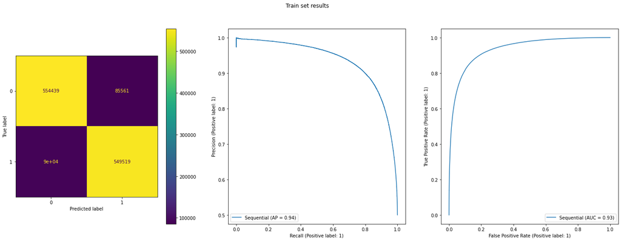

```python
y_train_pred_proba = model.predict(
    X_train,
    batch_size=128,
    workers=4,
    use_multiprocessing=True,
)

y_train_pred = [round(pred_proba[0]) for pred_proba in y_train_pred_proba]

viz_helpers.plot_classifier_results(
    model,
    X_train,
    y_train,
    y_train_pred,
    y_train_pred_proba,
    title="Train set results",
)
```

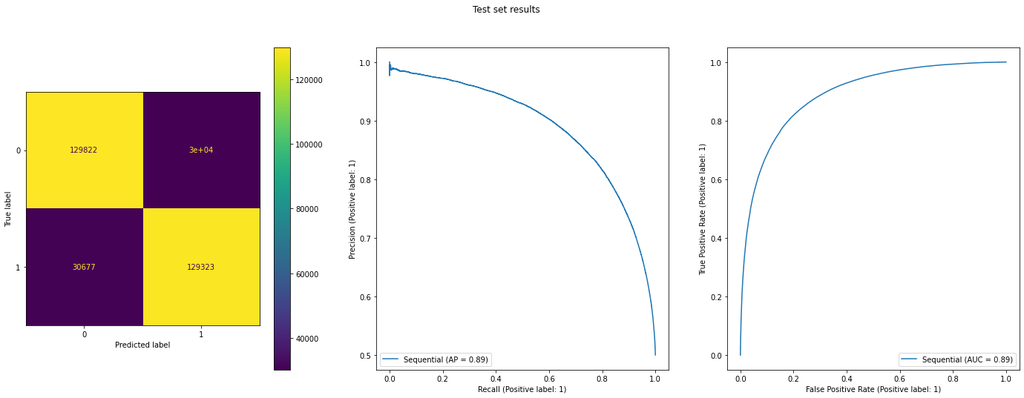

```python
y_test_pred_proba = model.predict(
    X_test,
    batch_size=128,
    workers=4,
    use_multiprocessing=True,
)

y_test_pred = [round(pred_proba[0]) for pred_proba in y_test_pred_proba]

viz_helpers.plot_classifier_results(
    model,
    X_test,
    y_test,
    y_test_pred,
    y_test_pred_proba,
    title="Test set results",
)
```

The performances on the train dataset is better than on the test datasets which indicates that our model has slightly over-fitted.

The performances on the dataset are much better than our baseline model :

- Average Precision = 0.89 (baseline = 0.73 , +22%)
- ROC AUC = 0.89 (baseline = 0.74 , +20%)

Our model is very well balanced : it predicted only 0.6% (baseline = 35% , -98%) more *NEGATIVE* (160499) messages than *POSITIVE* (159501).

### FFNN on SpaCy embedded documents

In this model, we use [SpaCy](https://spacy.io/api/doc#vector) to perform the text preprocessing (lemmatization and vectorization). The document vector represents the average of the SpaCy vectors of the tokens in the document.

The Neural Network architecture is the same as before.

```python
# Tokenizers, Stemmers and Lemmatizers
import spacy


# Processed data path
processed_data_path = os.path.join("..", "data", "processed")
vectorized_dataset_file_path = os.path.join(
    processed_data_path, "spacy_vectorized_dataset.pkl"
)


if os.path.exists(vectorized_dataset_file_path):
    # Load vectorized dataset
    with (open(vectorized_dataset_file_path, "rb")) as f:
        X = pickle.load(f)
else:
    # Download SpaCy model
    try:
        nlp = spacy.load("en_core_web_lg")
    except:
        !python -m spacy download en_core_web_lg
        nlp = spacy.load("en_core_web_lg")

    # Encode text
    X = [nlp(doc).vector for doc in tqdm(df.text)]

    # Save vectorized dataset as pickle
    with open(vectorized_dataset_file_path, "wb") as f:
        pickle.dump(X, f)
```

```python
from sklearn.model_selection import train_test_split


# Train-test split
X_train, X_test, y_train, y_test = train_test_split(
    X,
    df.target,
    test_size=0.2,
    stratify=df.target,
    random_state=42,
)
```

```python
import numpy as np
import tensorflow as tf
from keras.models import load_model
from keras.models import Sequential
from keras.layers import (
    Input,
    TextVectorization,
    Dense,
    Dropout,
    Activation,
)
from keras.callbacks import TensorBoard, EarlyStopping
from keras.metrics import AUC


model_name = "ffnn_on_spacy"
vector_size = len(X[0])

results_data_path = os.path.join("..", "results")
model_file_path = os.path.join(results_data_path, model_name)

if os.path.exists(model_file_path):
    # Load model
    model = load_model(model_file_path)
else:
    # define NN model
    model = Sequential(name=model_name)
    model.add(Dense(100, input_shape=(vector_size,), activation="relu"))
    model.add(Dropout(0.2))
    model.add(Dense(10, activation="relu"))
    model.add(Dense(1, activation="sigmoid"))

    # compile NN network
    model.compile(
        loss="binary_crossentropy",
        optimizer="adam",
        metrics=[
            "accuracy",
            AUC(curve="ROC", name="ROC_AUC"),
            AUC(curve="PR", name="AP"),
        ],
    )

    # fit NN model
    model.fit(
        np.stack(X_train, axis=0),
        y_train,
        epochs=10,
        batch_size=128,
        validation_split=0.2,
        callbacks=[
            TensorBoard(log_dir=f"logs/{model.name}"),
            EarlyStopping(monitor="val_loss", patience=2),
        ],
        workers=4,
        use_multiprocessing=True,
    )

    model.save(model_file_path)


print(model.summary())
```

[output not shown]

```
Model: "ffnn_on_spacy"
_________________________________________________________________
 Layer (type)                Output Shape              Param #
=================================================================
 dense (Dense)               (None, 100)               30100

 dropout (Dropout)           (None, 100)               0

 dense_1 (Dense)             (None, 10)                1010

 dense_2 (Dense)             (None, 1)                 11

=================================================================
Total params: 31,121
Trainable params: 31,121
Non-trainable params: 0
_________________________________________________________________
None
```

```python
y_train_pred_proba = model.predict(
    np.stack(X_train, axis=0),
    batch_size=128,
    workers=4,
    use_multiprocessing=True,
    verbose=1,
)
```

```
2022-01-17 04:37:36.980418: W tensorflow/core/framework/cpu_allocator_impl.cc:82] Allocation of 1536000000 exceeds 10% of free system memory.
```

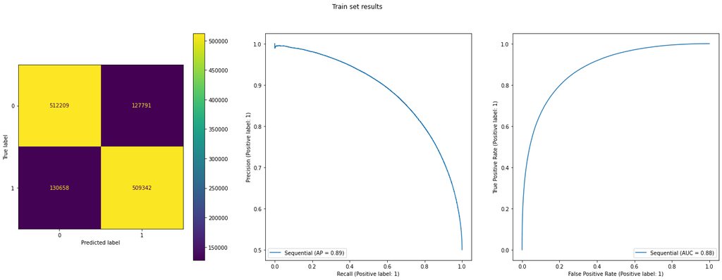

```python
y_train_pred = [round(pred_proba[0]) for pred_proba in y_train_pred_proba]

viz_helpers.plot_classifier_results(
    model,
    X_train,
    y_train,
    y_train_pred,
    y_train_pred_proba,
    title="Train set results",
)
```

```python
y_test_pred_proba = model.predict(
    np.stack(X_test, axis=0),
    batch_size=128,
    workers=4,
    use_multiprocessing=True,
)
```

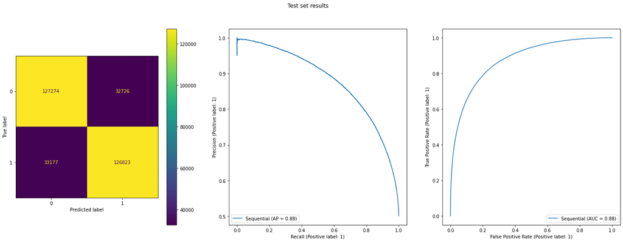

```python
y_test_pred = [round(pred_proba[0]) for pred_proba in y_test_pred_proba]

viz_helpers.plot_classifier_results(
    model,
    X_test,
    y_test,
    y_test_pred,
    y_test_pred_proba,
    title="Test set results",
)
```

The performances on the train and test datasets are similar which indicates that our model has not over-fitted.

### FFNN on Doc2Vec embedded documents

In this model, we train a Gensim [Doc2vec](https://radimrehurek.com/gensim/models/doc2vec.html) document embedding model to perform the text preprocessing (lemmatization and vectorization).

The Neural Network architecture is the same as before.

```python
from gensim.models.doc2vec import TaggedDocument, Doc2Vec
from gensim.utils import simple_preprocess


# Processed data path
processed_data_path = os.path.join("..", "data", "processed")
vectorized_dataset_file_path = os.path.join(
    processed_data_path, "doc2vec_vectorized_dataset.pkl"
)

if os.path.exists(vectorized_dataset_file_path):
    # Load vectorized dataset
    with (open(vectorized_dataset_file_path, "rb")) as f:
        X = pickle.load(f)
else:
    # Tag documents for training
    corpus = [
        TaggedDocument(words=simple_preprocess(doc), tags=[i])
        for i, doc in enumerate(df.text)
    ]

    # Train doc2vec model
    doc2vec = Doc2Vec()
    doc2vec.build_vocab(corpus)
    doc2vec.train(corpus, total_examples=doc2vec.corpus_count, epochs=doc2vec.epochs)

    # Vectorize text
    X = [doc2vec.infer_vector(doc.words) for doc in corpus]

    # Save vectorized dataset as pickle
    with open(vectorized_dataset_file_path, "wb") as f:
        pickle.dump(X, f)
```

[output not shown]

```python
from sklearn.model_selection import train_test_split


# Train-test split
X_train, X_test, y_train, y_test = train_test_split(
    X,
    df.target,
    test_size=0.2,
    stratify=df.target,
    random_state=42,
)
```

```python
import numpy as np
import tensorflow as tf
from keras.models import Sequential
from keras.layers import (
    Input,
    TextVectorization,
    Dense,
    Dropout,
    Activation,
    Embedding,
)
from keras.callbacks import TensorBoard, EarlyStopping
from keras.metrics import AUC


model_name = "ffnn_on_doc2vec"
vector_size = len(X[0])

results_data_path = os.path.join("..", "results")
model_file_path = os.path.join(results_data_path, model_name)

if os.path.exists(model_file_path):
    # Load model
    model = load_model(model_file_path)
else:
    # define NN model
    model = Sequential(name=model_name)
    model.add(Dense(100, input_shape=(vector_size,), activation="relu"))
    model.add(Dropout(0.2))
    model.add(Dense(10, activation="relu"))
    model.add(Dense(1, activation="sigmoid"))

    # compile NN network
    model.compile(
        loss="binary_crossentropy",
        optimizer="adam",
        metrics=[
            "accuracy",
            AUC(curve="ROC", name="ROC_AUC"),
            AUC(curve="PR", name="AP"),
        ],
    )

    # fit NN model
    model.fit(
        np.stack(X_train, axis=0),
        y_train,
        epochs=10,
        batch_size=128,
        validation_split=0.2,
        callbacks=[
            TensorBoard(log_dir=f"logs/{model.name}"),
            EarlyStopping(monitor="val_loss", patience=2),
        ],
        workers=4,
        use_multiprocessing=True,
    )

    model.save(model_file_path)


print(model.summary())
```

[output not shown]

```
2022-02-02 13:01:10.661569: W tensorflow/python/util/util.cc:368] Sets are not currently considered sequences, but this may change in the future, so consider avoiding using them.
```

```
INFO:tensorflow:Assets written to: ../results/ffnn_on_doc2vec/assets
```

```
INFO:tensorflow:Assets written to: ../results/ffnn_on_doc2vec/assets
```

```
Model: "ffnn_on_doc2vec"
_________________________________________________________________
 Layer (type)                Output Shape              Param #
=================================================================
 dense (Dense)               (None, 100)               10100

 dropout (Dropout)           (None, 100)               0

 dense_1 (Dense)             (None, 10)                1010

 dense_2 (Dense)             (None, 1)                 11

=================================================================
Total params: 11,121
Trainable params: 11,121
Non-trainable params: 0
_________________________________________________________________
None
```

```python
y_train_pred_proba = model.predict(
    np.stack(X_train, axis=0),
    batch_size=128,
    workers=4,
    use_multiprocessing=True,
    verbose=1,
)
```

```
2022-02-02 13:01:14.316397: W tensorflow/core/framework/cpu_allocator_impl.cc:82] Allocation of 512000000 exceeds 10% of free system memory.
```

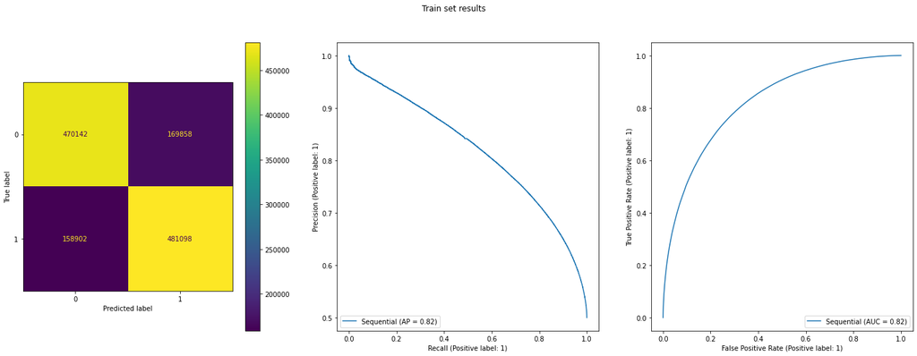

```python
y_train_pred = [round(pred_proba[0]) for pred_proba in y_train_pred_proba]

viz_helpers.plot_classifier_results(
    model,
    X_train,
    y_train,
    y_train_pred,
    y_train_pred_proba,
    title="Train set results",
)
```

```python
y_test_pred_proba = model.predict(
    np.stack(X_test, axis=0),
    batch_size=128,
    workers=4,
    use_multiprocessing=True,
)
```

```
2022-02-02 13:01:31.154682: W tensorflow/core/framework/cpu_allocator_impl.cc:82] Allocation of 128000000 exceeds 10% of free system memory.
```

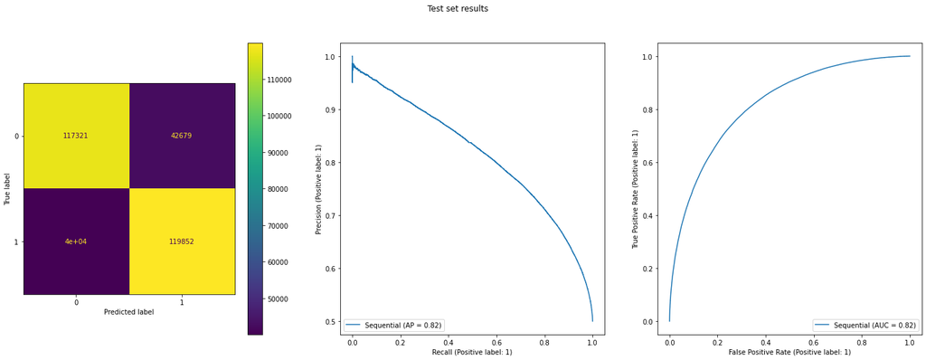

```python
y_test_pred = [round(pred_proba[0]) for pred_proba in y_test_pred_proba]

viz_helpers.plot_classifier_results(
    model,
    X_test,
    y_test,
    y_test_pred,
    y_test_pred_proba,
    title="Test set results",
)
```

The performances on the train and test datasets are similar which indicates that our model has not over-fitted.

The performances on the dataset are better than our baseline model, but not as good as our previous models :

- Average Precision = 0.82 (baseline = 0.73 , +12%)
- ROC AUC = 0.82 (baseline = 0.74 , +11%)

Our model is quite well balanced : it predicted only 3.2% (baseline = 35% , -91%) more *POSITIVE* (162531) messages than *NEGATIVE* (157469).

## FFNN models with Embedding layer

In the following models, we will add an embedding layer to our architecture. The goal of such layers is to represent words as vectors so that similar words have similar vectors, and that words meaning relations are kept (eg. : "Paris" is to "France" what "London" is to "England").

The input of an embedding layer is an encoded version of the text data. As a text pre-processing, we are going to test two encoding methods.

The Neural Network architecture after the embedding layer remains same as before.

### Embedding layer on simple encoded text

In this model, we will use a basic encoding method : each word is converted to a number.

```python
from sklearn.model_selection import train_test_split


# Train-test split
X_train, X_test, y_train, y_test = train_test_split(
    df.text,
    df.target,
    test_size=0.2,
    stratify=df.target,
    random_state=42,
)
```

```python
from keras.models import load_model
from keras.models import Sequential
from keras.layers import (
    Input,
    TextVectorization,
    Dense,
    Dropout,
    Activation,
    Flatten,
    Embedding,
)
from keras.callbacks import TensorBoard, EarlyStopping
from keras.metrics import AUC


# Model constants.
model_name = "ffnn_embedding_on_encoded"
max_features = 10000
embedding_dim = 100
sequence_length = 30


results_data_path = os.path.join("..", "results")
model_file_path = os.path.join(results_data_path, model_name)

if os.path.exists(model_file_path):
    # Load model
    model = load_model(model_file_path)
else:
    # Define vectorizer
    vectorize_layer = TextVectorization(
        output_mode="int",
        max_tokens=max_features,
        output_sequence_length=sequence_length,
    )
    vectorize_layer.adapt(
        df.text,
        batch_size=128,
    )

    # define NN model
    model = Sequential(name=model_name)
    model.add(Input(shape=(1,), dtype=tf.string))
    model.add(vectorize_layer)

    # Embedding layer
    model.add(
        Embedding(
            max_features,
            embedding_dim,
            input_length=sequence_length,
        )
    )
    model.add(Flatten())

    # Dense layers
    model.add(Dense(100, input_shape=(max_features,), activation="relu"))
    model.add(Dropout(0.2))
    model.add(Dense(10, activation="relu"))

    # Classification layer
    model.add(Dense(1, activation="sigmoid"))

    # compile NN network
    model.compile(
        loss="binary_crossentropy",
        optimizer="adam",
        metrics=[
            "accuracy",
            AUC(curve="ROC", name="ROC_AUC"),
            AUC(curve="PR", name="AP"),
        ],
    )

    # fit NN model
    model.fit(
        X_train,
        y_train,
        epochs=10,
        batch_size=128,
        validation_split=0.2,
        callbacks=[
            TensorBoard(log_dir=f"logs/{model.name}"),
            EarlyStopping(monitor="val_loss", patience=2),
        ],
        workers=4,
        use_multiprocessing=True,
    )

    model.save(model_file_path)


print(model.summary())
```

```
INFO:tensorflow:Assets written to: ../results/ffnn_embedding_on_encoded/assets
```

```
INFO:tensorflow:Assets written to: ../results/ffnn_embedding_on_encoded/assets
```

```
Model: "ffnn_embedding_on_encoded"
_________________________________________________________________
 Layer (type)                Output Shape              Param #
=================================================================
 text_vectorization_1 (TextV  (None, 30)               0
 ectorization)

 embedding_2 (Embedding)     (None, 30, 100)           1000000

 flatten_2 (Flatten)         (None, 3000)              0

 dense_6 (Dense)             (None, 100)               300100

 dropout_2 (Dropout)         (None, 100)               0

 dense_7 (Dense)             (None, 10)                1010

 dense_8 (Dense)             (None, 1)                 11

=================================================================
Total params: 1,301,121
Trainable params: 1,301,121
Non-trainable params: 0
_________________________________________________________________
None
```

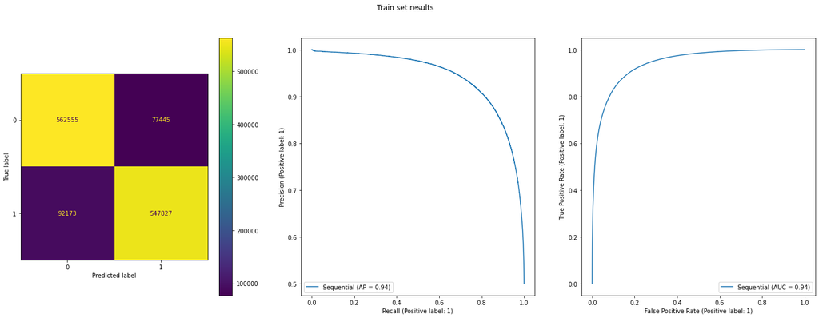

```python
y_train_pred_proba = model.predict(
    X_train,
    batch_size=128,
    workers=4,
    use_multiprocessing=True,
)

y_train_pred = [round(pred_proba[0]) for pred_proba in y_train_pred_proba]

viz_helpers.plot_classifier_results(
    model,
    X_train,
    y_train,
    y_train_pred,
    y_train_pred_proba,
    title="Train set results",
)
```

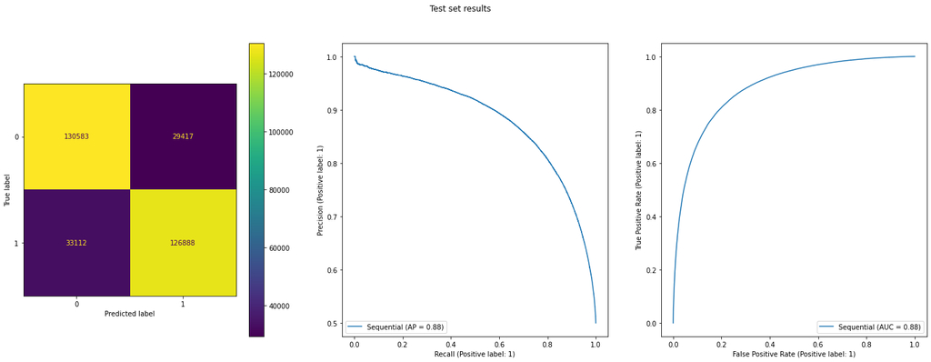

```python
y_test_pred_proba = model.predict(
    X_test,
    batch_size=128,
    workers=4,
    use_multiprocessing=True,
)

y_test_pred = [round(pred_proba[0]) for pred_proba in y_test_pred_proba]

viz_helpers.plot_classifier_results(
    model,
    X_test,
    y_test,
    y_test_pred,
    y_test_pred_proba,
    title="Test set results",
)
```

The performances on the train dataset is better than on the test datasets which indicates that our model has slightly over-fitted.

The performance on the test dataset is similar to our previous models.

This model is also more biased than the previous ones.

### Embedding layer on Bert encoded text

In this model, we will use a more sofisticated encoding method : we will use the [Bert](https://huggingface.co/docs/transformers/v4.15.0/en/tokenizer_summary#subword-tokenization) tokenizer to encode the text. This method does sub-word tokenization.

```python
# Tokenizers, Stemmers and Lemmatizers
from transformers import BertTokenizerFast


# Processed data path
processed_data_path = os.path.join("..", "data", "processed")
encoded_dataset_file_path = os.path.join(
    processed_data_path, "bert_encoded_dataset.pkl"
)

if os.path.exists(encoded_dataset_file_path):
    # Load encoded dataset
    with (open(encoded_dataset_file_path, "rb")) as f:
        X = pickle.load(f)
else:
    bert = BertTokenizerFast.from_pretrained("bert-base-uncased")

    # Encode text
    X = [bert.encode(doc) for doc in tqdm(df.text)]

    # Save vectorized dataset as pickle
    with open(encoded_dataset_file_path, "wb") as f:
        pickle.dump(X, f)
```

```python
from sklearn.model_selection import train_test_split
from keras.preprocessing.sequence import pad_sequences


# Pad sequences
X = pad_sequences(X, maxlen=max(map(len, X)), padding="post")

# Train-test split
X_train, X_test, y_train, y_test = train_test_split(
    X,
    df.target,
    test_size=0.2,
    stratify=df.target,
    random_state=42,
)
```

```python
from keras.models import load_model
from keras.models import Sequential
from keras.layers import (
    Input,
    TextVectorization,
    Dense,
    Dropout,
    Activation,
    Flatten,
    Embedding,
)
from keras.callbacks import TensorBoard, EarlyStopping
from keras.metrics import AUC


# Model constants.
model_name = "ffnn_embedding_on_bert"
embedding_dim = 100
max_features = max(map(max, X)) + 1
sequence_length = max(map(len, X))


results_data_path = os.path.join("..", "results")
model_file_path = os.path.join(results_data_path, model_name)

if os.path.exists(model_file_path):
    # Load model
    model = load_model(model_file_path)
else:
    # define NN model
    model = Sequential(name=model_name)

    # Embedding layer
    model.add(
        Embedding(
            max_features,
            embedding_dim,
            input_length=sequence_length,
        )
    )
    model.add(Flatten())

    # Dense layers
    model.add(Dense(100, input_shape=(max_features,), activation="relu"))
    model.add(Dropout(0.2))
    model.add(Dense(10, activation="relu"))

    # Classification layer
    model.add(Dense(1, activation="sigmoid"))

    # compile NN network
    model.compile(
        loss="binary_crossentropy",
        optimizer="adam",
        metrics=[
            "accuracy",
            AUC(curve="ROC", name="ROC_AUC"),
            AUC(curve="PR", name="AP"),
        ],
    )

    # fit NN model
    model.fit(
        X_train,
        y_train,
        epochs=10,
        batch_size=128,
        validation_split=0.2,
        callbacks=[
            TensorBoard(log_dir=f"logs/{model.name}"),
            EarlyStopping(monitor="val_loss", patience=2),
        ],
        workers=4,
        use_multiprocessing=True,
    )

    model.save(model_file_path)


print(model.summary())
```

```
Model: "ffnn_embedding_on_bert"
_________________________________________________________________
 Layer (type)                Output Shape              Param #
=================================================================
 embedding_1 (Embedding)     (None, 164, 100)          3026600

 flatten_1 (Flatten)         (None, 16400)             0

 dense_3 (Dense)             (None, 100)               1640100

 dropout_1 (Dropout)         (None, 100)               0

 dense_4 (Dense)             (None, 10)                1010

 dense_5 (Dense)             (None, 1)                 11

=================================================================
Total params: 4,667,721
Trainable params: 4,667,721
Non-trainable params: 0
_________________________________________________________________
None
```

```
2022-01-17 10:44:54.594106: W tensorflow/core/framework/cpu_allocator_impl.cc:82] Allocation of 839680000 exceeds 10% of free system memory.
```

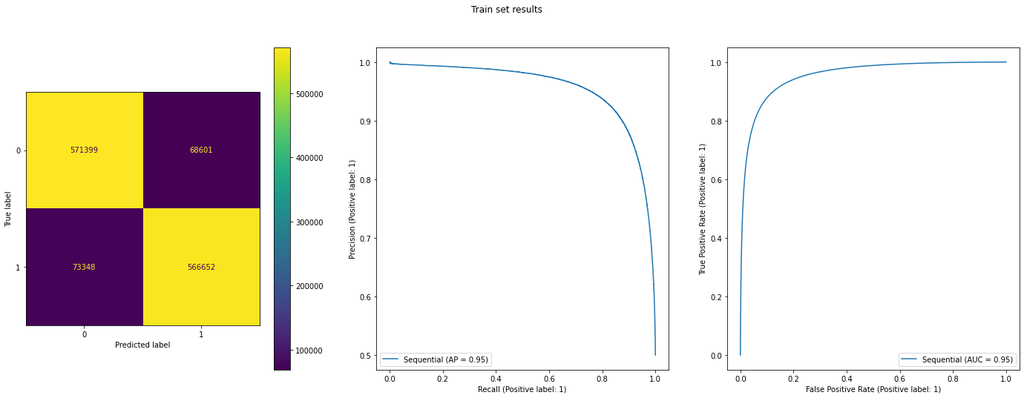

```python
y_train_pred_proba = model.predict(
    X_train,
    batch_size=128,
    workers=4,
    use_multiprocessing=True,
)

y_train_pred = [round(pred_proba[0]) for pred_proba in y_train_pred_proba]

viz_helpers.plot_classifier_results(
    model,
    X_train,
    y_train,
    y_train_pred,
    y_train_pred_proba,
    title="Train set results",
)
```

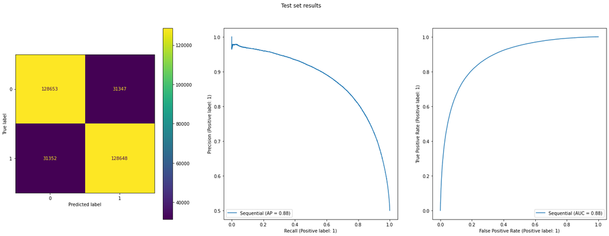

```python
y_test_pred_proba = model.predict(
    X_test,
    batch_size=128,
    workers=4,
    use_multiprocessing=True,
)

y_test_pred = [round(pred_proba[0]) for pred_proba in y_test_pred_proba]

viz_helpers.plot_classifier_results(
    model,
    X_test,
    y_test,
    y_test_pred,
    y_test_pred_proba,
    title="Test set results",
)
```

The performances on the train dataset is better than on the test datasets which indicates that our model has slightly over-fitted.

The performance on the test dataset is similar to our previous models.

One good thing : this model is almost perfectly balanced ! It predicted only 10 more *NEGATIVE* (160005) messages than *POSITIVE* (159995).

## RNN (Recurrent Neural Network) models

In the following models, we will add RNN or (Bidirectional-)LSTM layers to our architecture. The goal of such layers is to keep the information of the previous steps of the network when we are processing the next step.

The Neural Network architecture after the Recurrent layer remains same as before (with the Embedding layer).

### Simple RNN on Embedded text

In this model, we add a simple RNN to our model.

[figure not shown]

```python
from sklearn.model_selection import train_test_split


# Train-test split
X_train, X_test, y_train, y_test = train_test_split(
    df.text,
    df.target,
    test_size=0.2,
    stratify=df.target,
    random_state=42,
)
```

```python
from keras.models import load_model
from keras.models import Sequential
from keras.layers import (
    Input,
    TextVectorization,
    Dense,
    Dropout,
    Activation,
    Flatten,
    Embedding,
    SimpleRNN,
    GRU,
    LSTM,
)
from keras.callbacks import TensorBoard, EarlyStopping
from keras.metrics import AUC


# Model constants.
model_name = "rnn_on_embedded"
max_features = 10000
sequence_length = 30
embedding_dim = 100
rnn_units = 100


results_data_path = os.path.join("..", "results")
model_file_path = os.path.join(results_data_path, model_name)

if os.path.exists(model_file_path):
    # Load model
    model = load_model(model_file_path)
else:
    # Define vectorizer
    vectorize_layer = TextVectorization(
        output_mode="int",
        max_tokens=max_features,
        output_sequence_length=sequence_length,
    )
    vectorize_layer.adapt(
        df.text,
        batch_size=128,
    )

    # define NN model
    model = Sequential(name=model_name)
    model.add(Input(shape=(1,), dtype=tf.string))
    model.add(vectorize_layer)

    # Embedding layer
    model.add(
        Embedding(
            max_features,
            embedding_dim,
            input_length=sequence_length,
        )
    )

    # RNN layer
    model.add(SimpleRNN(units=rnn_units, dropout=0.2))

    # Dense layers
    model.add(Dense(100, input_shape=(max_features,), activation="relu"))
    model.add(Dropout(0.2))
    model.add(Dense(10, activation="relu"))

    # Classification layer
    model.add(Dense(1, activation="sigmoid"))

    # compile NN network
    model.compile(
        loss="binary_crossentropy",
        optimizer="adam",
        metrics=[
            "accuracy",
            AUC(curve="ROC", name="ROC_AUC"),
            AUC(curve="PR", name="AP"),
        ],
    )

    # fit NN model
    model.fit(
        X_train,
        y_train,
        epochs=10,
        batch_size=128,
        validation_split=0.2,
        callbacks=[
            TensorBoard(log_dir=f"logs/{model.name}"),
            EarlyStopping(monitor="val_loss", patience=2),
        ],
        workers=4,
        use_multiprocessing=True,
    )

    model.save(model_file_path)


print(model.summary())
```

```
INFO:tensorflow:Assets written to: ../results/rnn_on_encoded/assets
```

```
INFO:tensorflow:Assets written to: ../results/rnn_on_encoded/assets
```

```
Model: "rnn_on_encoded"
_________________________________________________________________
 Layer (type)                Output Shape              Param #
=================================================================
 text_vectorization_4 (TextV  (None, 30)               0
 ectorization)

 embedding_3 (Embedding)     (None, 30, 100)           1000000

 simple_rnn_2 (SimpleRNN)    (None, 100)               20100

 dense_9 (Dense)             (None, 100)               10100

 dropout_3 (Dropout)         (None, 100)               0

 dense_10 (Dense)            (None, 10)                1010

 dense_11 (Dense)            (None, 1)                 11

=================================================================
Total params: 1,031,221
Trainable params: 1,031,221
Non-trainable params: 0
_________________________________________________________________
None
```

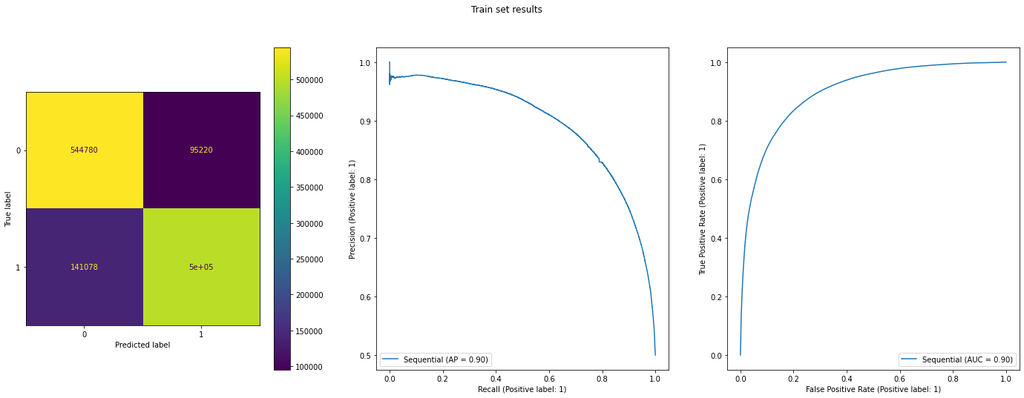

```python
y_train_pred_proba = model.predict(
    X_train,
    batch_size=128,
    workers=4,
    use_multiprocessing=True,
)

y_train_pred = [round(pred_proba[0]) for pred_proba in y_train_pred_proba]

viz_helpers.plot_classifier_results(
    model,
    X_train,
    y_train,
    y_train_pred,
    y_train_pred_proba,
    title="Train set results",
)
```

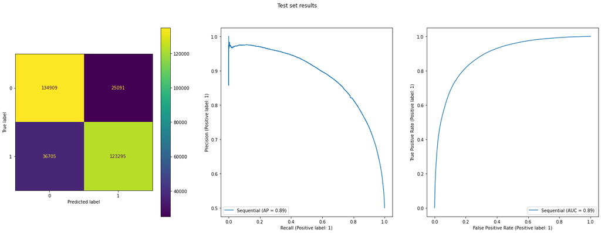

```python
y_test_pred_proba = model.predict(
    X_test,
    batch_size=128,
    workers=4,
    use_multiprocessing=True,
)

y_test_pred = [round(pred_proba[0]) for pred_proba in y_test_pred_proba]

viz_helpers.plot_classifier_results(
    model,
    X_test,
    y_test,
    y_test_pred,
    y_test_pred_proba,
    title="Test set results",
)
```

The performances on the train and test datasets are similar which indicates that our model has not over-fitted.

The performances on the dataset are slightly better than our previous models :

- Average Precision = 0.89 (baseline = 0.73 , +22%)
- ROC AUC = 0.89 (baseline = 0.74 , +20%)

Our model is much less biased than our baseline, but still leans towards the *NEGATIVE* class : it predicted 16% (baseline = 35% , -54%) more *NEGATIVE* (171614) messages than *POSITIVE* (148386).

### LSTM on Embedded text

In this model, we add a LSTM (Long short-term memory) layer in stead of the RNN layer.

[figure not shown]

```python
from sklearn.model_selection import train_test_split


# Train-test split
X_train, X_test, y_train, y_test = train_test_split(
    df.text,
    df.target,
    test_size=0.2,
    stratify=df.target,
    random_state=42,
)
```

```python
from keras.models import load_model
from keras.models import Sequential
from keras.layers import (
    Input,
    TextVectorization,
    Dense,
    Dropout,
    Activation,
    Flatten,
    Embedding,
    SimpleRNN,
    GRU,
    LSTM,
)
from keras.callbacks import TensorBoard, EarlyStopping
from keras.metrics import AUC


# Model constants.
model_name = "lstm_on_embedded"
max_features = 10000
sequence_length = 30
embedding_dim = 100
rnn_units = 100


results_data_path = os.path.join("..", "results")
model_file_path = os.path.join(results_data_path, model_name)

if os.path.exists(model_file_path):
    # Load model
    model = load_model(model_file_path)
else:
    # Define vectorizer
    vectorize_layer = TextVectorization(
        output_mode="int",
        max_tokens=max_features,
        output_sequence_length=sequence_length,
    )
    vectorize_layer.adapt(
        df.text,
        batch_size=128,
    )

    # define NN model
    model = Sequential(name=model_name)
    model.add(Input(shape=(1,), dtype=tf.string))
    model.add(vectorize_layer)

    # Embedding layer
    model.add(
        Embedding(
            max_features,
            embedding_dim,
            input_length=sequence_length,
        )
    )

    # LSTM layer
    model.add(LSTM(units=rnn_units, dropout=0.2))

    # Dense layers
    model.add(Dense(100, input_shape=(max_features,), activation="relu"))
    model.add(Dropout(0.2))
    model.add(Dense(10, activation="relu"))

    # Classification layer
    model.add(Dense(1, activation="sigmoid"))

    # compile NN network
    model.compile(
        loss="binary_crossentropy",
        optimizer="adam",
        metrics=[
            "accuracy",
            AUC(curve="ROC", name="ROC_AUC"),
            AUC(curve="PR", name="AP"),
        ],
    )

    # fit NN model
    model.fit(
        X_train,
        y_train,
        epochs=10,
        batch_size=128,
        validation_split=0.2,
        callbacks=[
            TensorBoard(log_dir=f"logs/{model.name}"),
            EarlyStopping(monitor="val_loss", patience=2),
        ],
        workers=4,
        use_multiprocessing=True,
    )

    model.save(model_file_path)


print(model.summary())
```

```
WARNING:absl:Found untraced functions such as lstm_cell_layer_call_fn, lstm_cell_layer_call_and_return_conditional_losses, lstm_cell_layer_call_fn, lstm_cell_layer_call_and_return_conditional_losses, lstm_cell_layer_call_and_return_conditional_losses while saving (showing 5 of 5). These functions wi…
```

```
INFO:tensorflow:Assets written to: ../results/lstm_on_embedded/assets
```

```
INFO:tensorflow:Assets written to: ../results/lstm_on_embedded/assets
WARNING:absl:<keras.layers.recurrent.LSTMCell object at 0x7f6d7eebf2b0> has the same name 'LSTMCell' as a built-in Keras object. Consider renaming <class 'keras.layers.recurrent.LSTMCell'> to avoid naming conflicts when loading with `tf.keras.models.load_model`. If renaming is not possible, pass the…
```

```
Model: "lstm_on_embedded"
_________________________________________________________________
 Layer (type)                Output Shape              Param #
=================================================================
 text_vectorization_6 (TextV  (None, 30)               0
 ectorization)

 embedding_5 (Embedding)     (None, 30, 100)           1000000

 lstm (LSTM)                 (None, 100)               80400

 dense_15 (Dense)            (None, 100)               10100

 dropout_5 (Dropout)         (None, 100)               0

 dense_16 (Dense)            (None, 10)                1010

 dense_17 (Dense)            (None, 1)                 11

=================================================================
Total params: 1,091,521
Trainable params: 1,091,521
Non-trainable params: 0
_________________________________________________________________
None
```

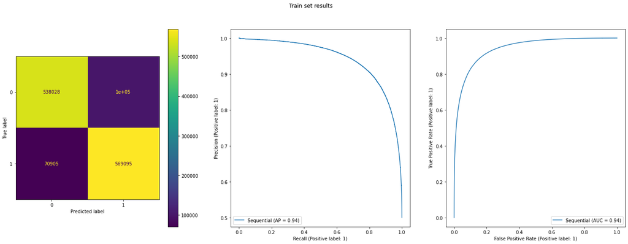

```python
y_train_pred_proba = model.predict(
    X_train,
    batch_size=128,
    workers=4,
    use_multiprocessing=True,
)

y_train_pred = [round(pred_proba[0]) for pred_proba in y_train_pred_proba]

viz_helpers.plot_classifier_results(
    model,
    X_train,
    y_train,
    y_train_pred,
    y_train_pred_proba,
    title="Train set results",
)
```

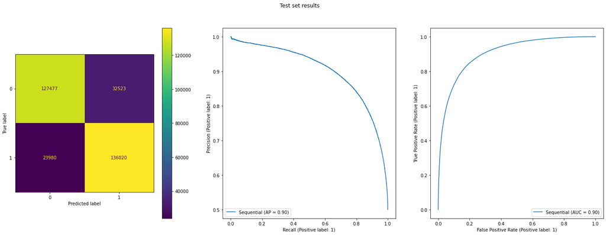

```python
y_test_pred_proba = model.predict(
    X_test,
    batch_size=128,
    workers=4,
    use_multiprocessing=True,
)

y_test_pred = [round(pred_proba[0]) for pred_proba in y_test_pred_proba]

viz_helpers.plot_classifier_results(
    model,
    X_test,
    y_test,
    y_test_pred,
    y_test_pred_proba,
    title="Test set results",
)
```

The performances on the train dataset is better than on the test datasets which indicates that our model has slightly over-fitted.

The performances on the dataset are slightly better than our previous models :

- Average Precision = 0.90 (baseline = 0.73 , +23%)
- ROC AUC = 0.90 (baseline = 0.74 , +22%)

Our model is much less biased than our baseline, but still leans towards the *POSITIVE* class : it predicted 11% (baseline = 35% , -69%) more *POSITIVE* (168543) messages than *NEGATIVE* (151457).

### Bidirectional LSTM on embedded text

In this model, we add a Bidirectional-LSTM layer in stead of the RNN layer. The goal of such layers is to use information from past (backwards) and future (forward) states simultaneously.

[figure not shown]

```python
from sklearn.model_selection import train_test_split


# Train-test split
X_train, X_test, y_train, y_test = train_test_split(
    df.text,
    df.target,
    test_size=0.2,
    stratify=df.target,
    random_state=42,
)
```

```python
from keras.models import load_model
from keras.models import Sequential
from keras.layers import (
    Input,
    TextVectorization,
    Dense,
    Dropout,
    Activation,
    Flatten,
    Embedding,
    Bidirectional,
    SimpleRNN,
    GRU,
    LSTM,
)
from keras.callbacks import TensorBoard, EarlyStopping
from keras.metrics import AUC


# Model constants.
model_name = "bidirectional_lstm_on_embedded"
max_features = 10000
sequence_length = 30
embedding_dim = 100
rnn_units = 100


results_data_path = os.path.join("..", "results")
model_file_path = os.path.join(results_data_path, model_name)

if os.path.exists(model_file_path):
    # Load model
    model = load_model(model_file_path)
else:
    # Define vectorizer
    vectorize_layer = TextVectorization(
        output_mode="int",
        max_tokens=max_features,
        output_sequence_length=sequence_length,
    )
    vectorize_layer.adapt(
        df.text,
        batch_size=128,
    )

    # define NN model
    model = Sequential(name=model_name)
    model.add(Input(shape=(1,), dtype=tf.string))
    model.add(vectorize_layer)

    # Embedding layer
    model.add(
        Embedding(
            max_features,
            embedding_dim,
            input_length=sequence_length,
        )
    )

    # Bidirectional LSTM layer
    model.add(Bidirectional(LSTM(units=rnn_units, dropout=0.2)))

    # Dense layers
    model.add(Dense(100, input_shape=(max_features,), activation="relu"))
    model.add(Dropout(0.2))
    model.add(Dense(10, activation="relu"))

    # Classification layer
    model.add(Dense(1, activation="sigmoid"))

    # compile NN network
    model.compile(
        loss="binary_crossentropy",
        optimizer="adam",
        metrics=[
            "accuracy",
            AUC(curve="ROC", name="ROC_AUC"),
            AUC(curve="PR", name="AP"),
        ],
    )

    # fit NN model
    model.fit(
        X_train,
        y_train,
        epochs=10,
        batch_size=128,
        validation_split=0.2,
        callbacks=[
            TensorBoard(log_dir=f"logs/{model.name}"),
            EarlyStopping(monitor="val_loss", patience=2),
        ],
        workers=4,
        use_multiprocessing=True,
    )

    model.save(model_file_path)


print(model.summary())
```

```
WARNING:absl:Found untraced functions such as lstm_cell_2_layer_call_fn, lstm_cell_2_layer_call_and_return_conditional_losses, lstm_cell_3_layer_call_fn, lstm_cell_3_layer_call_and_return_conditional_losses, lstm_cell_2_layer_call_fn while saving (showing 5 of 10). These functions will not be direct…
```

```
INFO:tensorflow:Assets written to: ../results/bidirectional_lstm_on_embedded/assets
```

[output not shown]

```
Model: "bidirectional_lstm_on_embedded"
_________________________________________________________________
 Layer (type)                Output Shape              Param #
=================================================================
 text_vectorization_7 (TextV  (None, 30)               0
 ectorization)

 embedding_6 (Embedding)     (None, 30, 100)           1000000

 bidirectional (Bidirectiona  (None, 200)              160800
 l)

 dense_18 (Dense)            (None, 100)               20100

 dropout_6 (Dropout)         (None, 100)               0

 dense_19 (Dense)            (None, 10)                1010

 dense_20 (Dense)            (None, 1)                 11

=================================================================
Total params: 1,181,921
Trainable params: 1,181,921
Non-trainable params: 0
_________________________________________________________________
None
```

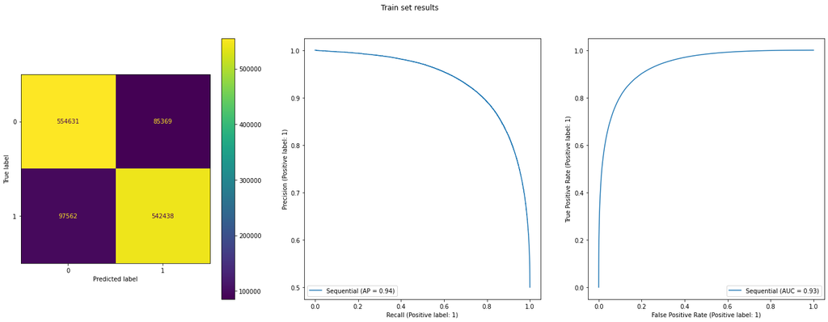

```python
y_train_pred_proba = model.predict(
    X_train,
    batch_size=128,
    workers=4,
    use_multiprocessing=True,
)

y_train_pred = [round(pred_proba[0]) for pred_proba in y_train_pred_proba]

viz_helpers.plot_classifier_results(
    model,
    X_train,
    y_train,
    y_train_pred,
    y_train_pred_proba,
    title="Train set results",
)
```

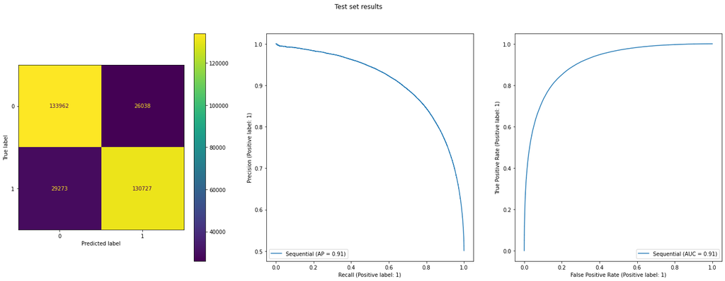

```python
y_test_pred_proba = model.predict(
    X_test,
    batch_size=128,
    workers=4,
    use_multiprocessing=True,
)

y_test_pred = [round(pred_proba[0]) for pred_proba in y_test_pred_proba]

viz_helpers.plot_classifier_results(
    model,
    X_test,
    y_test,
    y_test_pred,
    y_test_pred_proba,
    title="Test set results",
)
```

The performances on the train dataset is better than on the test datasets which indicates that our model has slightly over-fitted.

The performances on the dataset are slightly better than our previous models :

- Average Precision = 0.91 (baseline = 0.73 , +25%)
- ROC AUC = 0.91 (baseline = 0.74 , +23%)

Our model is much almost not biased biased! It still slightly leans towards the *NEGATIVE* class : it predicted only 4.1% (baseline = 35% , -88%) more *NEGATIVE* (163235) messages than *POSITIVE* (156765).

### Stacked Bidirectional-LSTM layers on Embedded text

In this model, we add a second Bidirectional-LSTM layer.

[figure not shown]

```python
from sklearn.model_selection import train_test_split


# Train-test split
X_train, X_test, y_train, y_test = train_test_split(
    df.text,
    df.target,
    test_size=0.2,
    stratify=df.target,
    random_state=42,
)
```

```python
from keras.models import load_model
from keras.models import Sequential
from keras.layers import (
    Input,
    TextVectorization,
    Dense,
    Dropout,
    Activation,
    Flatten,
    Embedding,
    Bidirectional,
    SimpleRNN,
    GRU,
    LSTM,
)
from keras.callbacks import TensorBoard, EarlyStopping
from keras.metrics import AUC


# Model constants.
model_name = "bidirectional_lstm_with_return_sequences_on_embedded"
max_features = 10000
sequence_length = 30
embedding_dim = 100
rnn_units = 100


results_data_path = os.path.join("..", "results")
model_file_path = os.path.join(results_data_path, model_name)

if os.path.exists(model_file_path):
    # Load model
    model = load_model(model_file_path)
else:
    # Define vectorizer
    vectorize_layer = TextVectorization(
        output_mode="int",
        max_tokens=max_features,
        output_sequence_length=sequence_length,
    )
    vectorize_layer.adapt(
        df.text,
        batch_size=128,
    )

    # define NN model
    model = Sequential(name=model_name)
    model.add(Input(shape=(1,), dtype=tf.string))
    model.add(vectorize_layer)

    # Embedding layer
    model.add(
        Embedding(
            max_features,
            embedding_dim,
            input_length=sequence_length,
        )
    )

    # Bidirectional LSTM layer
    model.add(Bidirectional(LSTM(units=rnn_units, dropout=0.2, return_sequences=True)))
    model.add(Bidirectional(LSTM(units=rnn_units, dropout=0.2)))

    # Dense layers
    model.add(Dense(100, input_shape=(max_features,), activation="relu"))
    model.add(Dropout(0.2))
    model.add(Dense(10, activation="relu"))

    # Classification layer
    model.add(Dense(1, activation="sigmoid"))

    # compile NN network
    model.compile(
        loss="binary_crossentropy",
        optimizer="adam",
        metrics=[
            "accuracy",
            AUC(curve="ROC", name="ROC_AUC"),
            AUC(curve="PR", name="AP"),
        ],
    )

    # fit NN model
    model.fit(
        X_train,
        y_train,
        epochs=10,
        batch_size=128,
        validation_split=0.2,
        callbacks=[
            TensorBoard(log_dir=f"logs/{model.name}"),
            EarlyStopping(monitor="val_loss", patience=2),
        ],
        workers=4,
        use_multiprocessing=True,
    )

    model.save(model_file_path)


print(model.summary())
```

```
WARNING:absl:Found untraced functions such as lstm_cell_5_layer_call_fn, lstm_cell_5_layer_call_and_return_conditional_losses, lstm_cell_6_layer_call_fn, lstm_cell_6_layer_call_and_return_conditional_losses, lstm_cell_8_layer_call_fn while saving (showing 5 of 20). These functions will not be direct…
```

```
INFO:tensorflow:Assets written to: ../results/bidirectional_lstm_with_return_sequences_on_embedded/assets
```

[output not shown]

```
Model: "bidirectional_lstm_with_return_sequences_on_embedded"
_________________________________________________________________
 Layer (type)                Output Shape              Param #
=================================================================
 text_vectorization_8 (TextV  (None, 30)               0
 ectorization)

 embedding_7 (Embedding)     (None, 30, 100)           1000000

 bidirectional_1 (Bidirectio  (None, 30, 200)          160800
 nal)

 bidirectional_2 (Bidirectio  (None, 200)              240800
 nal)

 dense_21 (Dense)            (None, 100)               20100

 dropout_7 (Dropout)         (None, 100)               0

 dense_22 (Dense)            (None, 10)                1010

 dense_23 (Dense)            (None, 1)                 11

=================================================================
Total params: 1,422,721
Trainable params: 1,422,721
Non-trainable params: 0
_________________________________________________________________
None
```

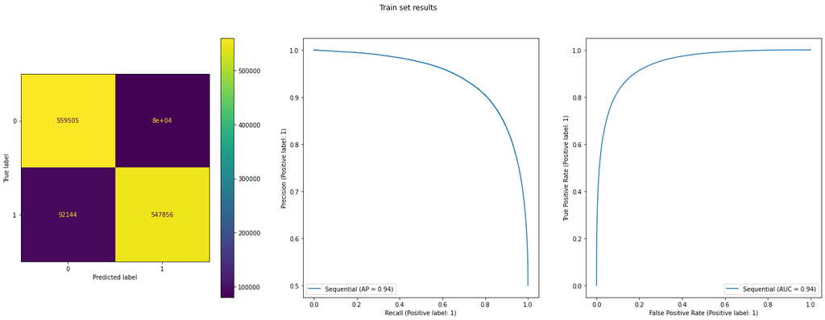

```python
y_train_pred_proba = model.predict(
    X_train,
    batch_size=128,
    workers=4,
    use_multiprocessing=True,
)

y_train_pred = [round(pred_proba[0]) for pred_proba in y_train_pred_proba]

viz_helpers.plot_classifier_results(
    model,
    X_train,
    y_train,
    y_train_pred,
    y_train_pred_proba,
    title="Train set results",
)
```

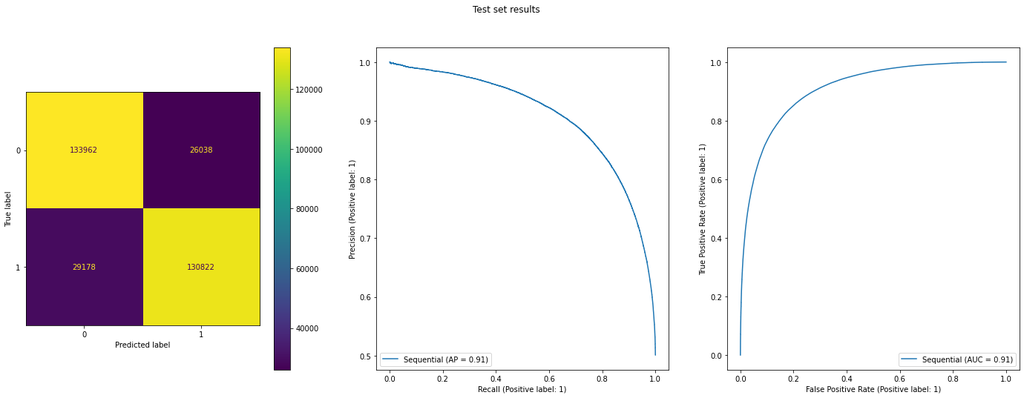

```python
y_test_pred_proba = model.predict(
    X_test,
    batch_size=128,
    workers=4,
    use_multiprocessing=True,
)

y_test_pred = [round(pred_proba[0]) for pred_proba in y_test_pred_proba]

viz_helpers.plot_classifier_results(
    model,
    X_test,
    y_test,
    y_test_pred,
    y_test_pred_proba,
    title="Test set results",
)
```

The performances on the train dataset is better than on the test datasets which indicates that our model has slightly over-fitted.

- Average Precision = 0.91 (baseline = 0.73 , +25%)
- ROC AUC = 0.91 (baseline = 0.74 , +23%)

Our model is much almost not biased biased! It still slightly leans towards the *NEGATIVE* class : it predicted only 4.0% (baseline = 35% , -89%) more *NEGATIVE* (163140) messages than *POSITIVE* (156860).